# Instacart Market Basket Challenge - Exploratory Data Analysis and Predictive Modeling

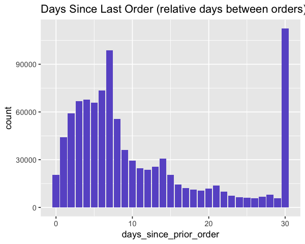

```r
orders %>%
  ggplot(aes(x=days_since_prior_order)) +
geom_histogram(stat="count",fill="slateblue") + ggtitle("Days Since Last Order (relative days between orders)")
```

### What are the most popular items ordered on Instacart?

```r
mostcommon <- order_products_train %>%
  group_by(product_id) %>%
  summarize(count = n()) %>%
  top_n(10, wt = count) %>%
  left_join(select(products,product_id,product_name),by="product_id") %>%
  arrange(desc(count))

head(mostcommon, n=10)
```

| product_id | count | product_name |
| --- | --- | --- |
| 24852 | 18726 | Banana |
| 13176 | 15480 | Bag of Organic Bananas |
| 21137 | 10894 | Organic Strawberries |
| 21903 | 9784 | Organic Baby Spinach |
| 47626 | 8135 | Large Lemon |
| 47766 | 7409 | Organic Avocado |
| 47209 | 7293 | Organic Hass Avocado |
| 16797 | 6494 | Strawberries |
| 26209 | 6033 | Limes |
| 27966 | 5546 | Organic Raspberries |

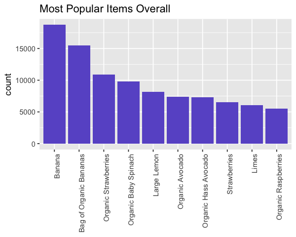

```r
mostcommon %>%
  ggplot(aes(x=reorder(product_name,-count), y=count))+
  geom_bar(stat="identity",fill="slateblue")+
theme(axis.text.x=element_text(angle=90, hjust=1),axis.title.x = element_blank()) +  ggtitle("Most Popular Items Overall")
```

### What items are most often reordered?

```r
item_reorders <- order_products_train %>%
  group_by(product_id) %>%
  summarize(proportion_reordered = mean(reordered), n=n()) %>%
  filter(n>40) %>%
  top_n(10,wt=proportion_reordered) %>%
  arrange(desc(proportion_reordered)) %>%
  left_join(products,by="product_id")

head(data.frame(item_reorders), n=15)
```

A data.frame: 10 × 6

| product_id <int> | proportion_reordered <dbl> | n <int> | product_name <fct> | aisle_id <int> | department_id <int> |
| --- | --- | --- | --- | --- | --- |
| 1729 | 0.9347826 | 92 | 2% Lactose Free Milk | 84 | 16 |
| 20940 | 0.9130435 | 368 | Organic Low Fat Milk | 84 | 16 |
| 12193 | 0.8983051 | 59 | 100% Florida Orange Juice | 98 | 7 |
| 21038 | 0.8888889 | 81 | Organic Spelt Tortillas | 128 | 3 |
| 31764 | 0.8888889 | 45 | Original Sparkling Seltzer Water Cans | 115 | 7 |
| 24852 | 0.8841717 | 18726 | Banana | 24 | 4 |
| 117 | 0.8833333 | 120 | Petit Suisse Fruit | 2 | 16 |
| 39180 | 0.8819876 | 483 | Organic Lowfat 1% Milk | 84 | 16 |
| 12384 | 0.8810409 | 269 | Organic Lactose Free 1% Lowfat Milk | 91 | 16 |
| 24024 | 0.8785249 | 461 | 1% Lowfat Milk | 84 | 16 |

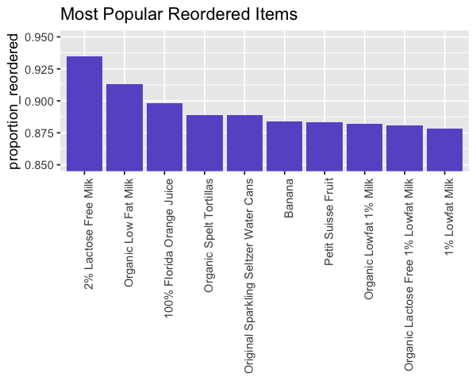

```r
item_reorders %>%
  ggplot(aes(x=reorder(product_name,-proportion_reordered), y=proportion_reordered))+
  geom_bar(stat="identity",fill="slateblue")+
  theme(axis.text.x=element_text(angle=90, hjust=1),axis.title.x = element_blank())+coord_cartesian(ylim=c(0.85,0.95)) + ggtitle("Most Popular Reordered Items")
```

## Proportion of Products Reordered

A data.frame: 2 × 3

| reordered <int> | n <int> | prop <dbl> |
| --- | --- | --- |
| 0 | 555793 | 0.4014056 |
| 1 | 828824 | 0.5985944 |

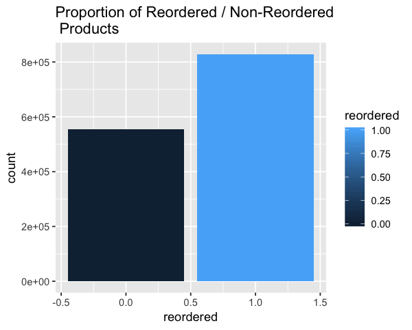

```r
reorder.table<- order_products_train %>%
  count(reordered) %>%
  mutate(prop = prop.table(n))

as.data.frame(reorder.table)

reorder <- order_products_train %>%
  group_by(reordered) %>%
  summarize(count = n()) %>%
  mutate(proportion = count/sum(count))

reorder %>%
  ggplot(aes(x=reordered,y=count, fill=reordered))+
geom_bar(stat="identity")+ggtitle("Proportion of Reordered / Non-Reordered\n Products")
```

## Now let's take a look at some specific "Power" Instacart users

```r
# First calculating proportion of reorders per order and n number of products in a single order
power.users <- order_products_prior %>%
  group_by(order_id) %>%
  summarize(reordered.prop = mean(reordered),n=n()) %>%
  right_join(filter(orders,order_number>2), by="order_id")
# take out first order (reordered response column is irrelevant fir first orders)
# for each order, calculating reordered.prop, then joining with orders table to add reordered.prop and n

power.users2 <- power.users %>%
  filter(eval_set =="prior") %>%
  group_by(user_id) %>%
  summarize(orders_total = sum(reordered.prop==1,na.rm=T), percent_equal = orders_total/n()) %>%
  filter(percent_equal == 1) %>%
arrange(desc(orders_total))
# lists users with 100% reorders in the order of highest number of total orders

head(power.users2, n=10)
head(power.users)
```

| user_id | orders_total | percent_equal |
| --- | --- | --- |
| 99753 | 97 | 1 |
| 55331 | 49 | 1 |
| 106510 | 49 | 1 |
| 111365 | 47 | 1 |
| 74656 | 46 | 1 |
| 170174 | 45 | 1 |
| 12025 | 43 | 1 |
| 164779 | 37 | 1 |
| 37075 | 34 | 1 |
| 110225 | 33 | 1 |

| order_id | reordered.prop | n | user_id | eval_set | order_number | order_dow | order_hour_of_day | days_since_prior_order |
| --- | --- | --- | --- | --- | --- | --- | --- | --- |
| 473747 | 0.6000000 | 5 | 1 | prior | 3 | 3 | 12 | 21 |
| 2254736 | 1.0000000 | 5 | 1 | prior | 4 | 4 | 7 | 29 |
| 431534 | 0.6250000 | 8 | 1 | prior | 5 | 4 | 15 | 28 |
| 3367565 | 1.0000000 | 4 | 1 | prior | 6 | 2 | 7 | 19 |
| 550135 | 1.0000000 | 5 | 1 | prior | 7 | 1 | 9 | 20 |
| 3108588 | 0.6666667 | 6 | 1 | prior | 8 | 1 | 14 | 14 |

#### User 99753 and 55331 have the highest frequency of orders AND the highest proportions of reorders per individual order.

Below are lists of the specific items ordered across orders for each of the two "Power Users." Notice that the number of products purchased per order is not considered in our identification of the "Power Users."

```r
power.order.numbers <- filter(power.users, user_id == 99753)$order_id
power.products <- order_products_prior %>%
  filter(order_id %in% power.order.numbers) %>%
  left_join(products, by="product_id")

head(power.products, n=10)[,1:5]

power.order.numbers <- filter(power.users, user_id == 55331)$order_id
power.products <- order_products_prior %>%
  filter(order_id %in% power.order.numbers) %>%
  left_join(products, by="product_id")

head(power.products, n=10)[,1:5]
```

| order_id | product_id | add_to_cart_order | reordered | product_name |
| --- | --- | --- | --- | --- |
| 46614 | 27845 | 1 | 1 | Organic Whole Milk |
| 46614 | 38689 | 2 | 1 | Organic Reduced Fat Milk |
| 67223 | 27845 | 1 | 1 | Organic Whole Milk |
| 67223 | 38689 | 2 | 1 | Organic Reduced Fat Milk |
| 214506 | 27845 | 1 | 1 | Organic Whole Milk |
| 214506 | 38689 | 2 | 1 | Organic Reduced Fat Milk |
| 240832 | 27845 | 1 | 1 | Organic Whole Milk |
| 240832 | 38689 | 2 | 1 | Organic Reduced Fat Milk |
| 260804 | 27845 | 1 | 1 | Organic Whole Milk |
| 260804 | 38689 | 2 | 1 | Organic Reduced Fat Milk |

| order_id | product_id | add_to_cart_order | reordered | product_name |
| --- | --- | --- | --- | --- |
| 19195 | 21333 | 1 | 1 | Original Whipped Cream Cheese |
| 19195 | 17744 | 2 | 1 | Dark Chocolate with A Touch Of Sea Salt |
| 19195 | 40028 | 3 | 1 | Deluxe Cinnamon Raisin Bagels |
| 47826 | 21333 | 1 | 1 | Original Whipped Cream Cheese |
| 47826 | 6723 | 2 | 1 | Palmiers, Petite |
| 47826 | 17744 | 3 | 1 | Dark Chocolate with A Touch Of Sea Salt |
| 47826 | 40028 | 4 | 1 | Deluxe Cinnamon Raisin Bagels |
| 71579 | 17744 | 1 | 1 | Dark Chocolate with A Touch Of Sea Salt |
| 71579 | 40028 | 2 | 1 | Deluxe Cinnamon Raisin Bagels |
| 115171 | 17744 | 1 | 1 | Dark Chocolate with A Touch Of Sea Salt |

## What's Next??

### Predictive Analysis

Now that we have a better picture about the data we're working with, we can begin to use our best judgement to train models based on our historical data and test the models to see which ones work best on unseen data.

## Preprocessing

Before diving into the models, we must first reorganize the data to be able to easily fit the models using our data. For smoother computability, we will decrease the size of the overall data, Combined.orders by 1/4 using random sampling. We will merge the aisles and department data sets at a later point.

```r
All.Orders = merge(order_products_prior, orders)
All.Orders2 = merge(order_products_train, orders, by="order_id")
Combined.Orders = rbind(All.Orders,All.Orders2)
Combined.Orders <- merge(Combined.Orders, products, by = "product_id")
Combined.Orders$reordered <- as.factor(Combined.Orders$reordered)

set.seed(1)

subset <- sample(nrow(Combined.Orders),nrow(Combined.Orders)/4 )
Combined.Orders <- Combined.Orders[subset,]
nrow(Combined.Orders)
```

2587444

```r
attach(Combined.Orders)
Combined.Orders$department_id <- as.factor(Combined.Orders$department_id)
Combined.Orders$user_id <- as.factor(Combined.Orders$user_id)

# Sort Combined.Orders by user_id
Combined.Orders <- Combined.Orders[order(user_id),]
```

### Main Approach to Organizing the Variables

#### 1. Feature Engineering

A few new columns we created for the purpose of evaluating association of particular variables (specific users and productss) with the reordered response

1. user_prop_reordered: proportion of products reordered for each user for all products
2. total_orders: total number of orders for each user
3. reordered.Num: total number of reorders per product
4. proportion_reordered: proportion of reorders per product and per user

#### 2. Selection of Variables

- Some of the variables we were able to automatically take out, since they were either originally created for referential purposes only (ie eval_set, user_id, order_id, order_number, product_name)
- Others we took out since we had already created information about the users and proportion of reordered items across for each product
- Out of aisle, product, and departmental categories for the products, we decided to keep only one of these variables, since they are all correlated and related to one another

#### 3. Null Values: Non-random Missing Data

- The variable days_since_prior_order had a null value assigned to the first order made for every customer (since this variable is measured as a relative unit of time between orders). We decided to omit all of these first orders, since our response variable of specific reordered products is also measured relative to the products purchased in the first orders.

### Creation of Dataframes for Proportion Reordered per User (User.Reordered and User.data)

```r
User.data <- data.frame(unique(Combined.Orders[,5]))

User.Reordered <-Combined.Orders %>%
  group_by(user_id) %>%
  count(reordered)

User.Reordered[1:14,]
```

A tibble: 14 × 3

| user_id <fct> | reordered <fct> | n <int> |
| --- | --- | --- |
| 1 | 0 | 2 |
| 1 | 1 | 16 |
| 2 | 0 | 27 |
| 2 | 1 | 32 |
| 3 | 0 | 6 |
| 3 | 1 | 21 |
| 4 | 0 | 4 |
| 4 | 1 | 1 |
| 5 | 0 | 9 |
| 5 | 1 | 3 |
| 6 | 0 | 6 |
| 6 | 1 | 1 |
| 7 | 0 | 11 |
| 7 | 1 | 41 |

```r
# Create list of unique user_id's
id.list <- unique(Combined.Orders$user_id)
re.prop <- c()

# Calculating proportion of items reordered for each user in id.list
for (userid in id.list)
{
  subset <- User.Reordered[User.Reordered$user_id==userid,]
  if (nrow(subset)==1){
    if (subset$reordered == 0){
      pro = 0
    }
    else {
      pro = 1
    }
    }
  else
  {
    total <- sum(subset$n)
    pro <- subset$n[subset$reordered==1]/total
  }
  re.prop <- append(re.prop, pro)
}
```

```r
User.data <- data.frame(user_id=id.list, reorder.prop=re.prop)
```

```r
head(User.data, n=10)
```

A data.frame: 10 × 2

[output not shown]

```r
Combined.Orders$reordered.num <- as.numeric(Combined.Orders$reordered)-1

#########   User  Proportion Reorders
group_userid <- group_by(Combined.Orders, Combined.Orders$user_id)

User_Reorders = summarise(group_userid, total_orders=n())
User_Reorders$user_prop_reordered = User.data$reorder.prop
```

```r
head(User_Reorders)
```

A tibble: 6 × 3

[output not shown]

### Creation of Dataframe for Proportion Reordered per Product (item_reorders)

```r
item_reorders <- Combined.Orders %>%
  group_by(product_id) %>%
  summarize(n=n())

# Create list of unique product_id's
prodid.list <- (unique(Combined.Orders$product_id))
prodid.list <- sort(prodid.list)

re.prop <- c()
```

```r
head(item_reorders)
```

A tibble: 6 × 2

| product_id <int> | n <int> |
| --- | --- |
| 1 | 147 |
| 2 | 10 |
| 3 | 37 |
| 4 | 21 |
| 7 | 6 |
| 8 | 7 |

```r
# Sort Combined.Orders by product_id for easier parsing in for loop below
Combined.Orders <- Combined.Orders[order(Combined.Orders$product_id),]
attach(Combined.Orders)
```

```r
for (prodid in prodid.list)
{
  subset <- Combined.Orders[Combined.Orders$product_id==prodid,]
  if (nrow(subset)==1){
    if (subset$reordered == 0){
      pro=0
    }
    else {
      pro = 1
    }
  }
  else
  {
    total <- nrow(subset)
    pro <- nrow(subset[subset$reordered==1,])/total
    if (length(pro) == 0) {
      pro= 0
    }
  }
  re.prop <- append(re.prop, pro)
}
```

```r
item_reorders$proportion_reordered <- re.prop
ProductCounts <- item_reorders
```

```r
ProductCounts$product_orders <- ProductCounts$n
ProductCounts<- ProductCounts[,-2]
```

```r
head(ProductCounts)
```

A tibble: 6 × 3

| product_id <int> | proportion_reordered <dbl> | product_orders <int> |
| --- | --- | --- |
| 1 | 0.5986395 | 147 |
| 2 | 0.2000000 | 10 |
| 3 | 0.7567568 | 37 |
| 4 | 0.3809524 | 21 |
| 7 | 0.3333333 | 6 |
| 8 | 0.2857143 | 7 |

## Completing the Dataset

```r
# Merge Combined.Orders with ProductCounts
Combined.Orders <- merge(ProductCounts, Combined.Orders, by = "product_id")
```

```r
# Merge Combined.Orders with user_Reorders
User_Reorders$user_id <- User_Reorders$'Combined.Orders$user_id'
User_Reorders <- User_Reorders[,-1]
Combined.Orders <- merge(User_Reorders, Combined.Orders , by = "user_id")
Combined.Orders$order_dow <- as.factor(Combined.Orders$order_dow)
names(Combined.Orders)[6] <- 'product_orders_total'
```

```r
Combined.Orders$reordered <- as.factor(Combined.Orders$reordered)
Combined.Orders$department_id = as.factor(Combined.Orders$department_id)
```

```r
head(Combined.Orders)
```

A data.frame: 6 × 20

[output not shown]

```r
str(Combined.Orders)
```

[output not shown]

#### Eliminating the null values (in days_since_prior_order) as was discussed in previous section (#3 in Preprocessing section)

```r
Combined.Orders <- na.omit(Combined.Orders)
```

```r
head(Combined.Orders, n=10)
```

A data.frame: 10 × 18

| user_id <fct> | total_orders <int> | user_prop_reordered <dbl> | product_id <int> | proportion_reordered <dbl> | product_orders_total <int> | order_id <int> | add_to_cart_order <int> | reordered <fct> | eval_set <fct> | order_number <int> | order_dow <fct> | order_hour_of_day <int> | days_since_prior_order <int> | product_name <fct> | aisle_id <int> | department_id <fct> | reordered.num <dbl> |
| --- | --- | --- | --- | --- | --- | --- | --- | --- | --- | --- | --- | --- | --- | --- | --- | --- | --- |
| 1 | 18 | 0.8888889 | 12427 | 0.7584830 | 501 | 550135 | 3 | 1 | prior | 7 | 1 | 9 | 20 | Original Beef Jerky | 23 | 19 | 1 |
| 1 | 18 | 0.8888889 | 12427 | 0.7584830 | 501 | 3367565 | 2 | 1 | prior | 6 | 2 | 7 | 19 | Original Beef Jerky | 23 | 19 | 1 |
| 1 | 18 | 0.8888889 | 12427 | 0.7584830 | 501 | 431534 | 2 | 1 | prior | 5 | 4 | 15 | 28 | Original Beef Jerky | 23 | 19 | 1 |
| 1 | 18 | 0.8888889 | 39657 | 0.7667494 | 403 | 2550362 | 3 | 0 | prior | 10 | 4 | 8 | 30 | Milk Chocolate Almonds | 45 | 19 | 0 |
| 1 | 18 | 0.8888889 | 13032 | 0.6328671 | 286 | 2550362 | 8 | 1 | prior | 10 | 4 | 8 | 30 | Cinnamon Toast Crunch | 121 | 14 | 1 |
| 1 | 18 | 0.8888889 | 196 | 0.7835052 | 3007 | 3108588 | 2 | 1 | prior | 8 | 1 | 14 | 14 | Soda | 77 | 7 | 1 |
| 1 | 18 | 0.8888889 | 39657 | 0.7667494 | 403 | 1187899 | 5 | 1 | train | 11 | 4 | 8 | 14 | Milk Chocolate Almonds | 45 | 19 | 1 |
| 1 | 18 | 0.8888889 | 25133 | 0.7309237 | 498 | 2550362 | 5 | 1 | prior | 10 | 4 | 8 | 30 | Organic String Cheese | 21 | 16 | 1 |
| 1 | 18 | 0.8888889 | 26405 | 0.4811321 | 106 | 2254736 | 5 | 1 | prior | 4 | 4 | 7 | 29 | XL Pick-A-Size Paper Towel Rolls | 54 | 17 | 1 |
| 1 | 18 | 0.8888889 | 17122 | 0.6783285 | 1029 | 431534 | 6 | 0 | prior | 5 | 4 | 15 | 28 | Honeycrisp Apples | 24 | 4 | 0 |

# Modeling

## Splitting the Data

Now that we have reorganized the data by creating additional variables to consider that give us information about various proportions of reordered products, we can now split the data into a training set to train the data and a test/validation set to test the generalizability of our model.

```r
set.seed(1)
Train<- sample(1:nrow(Combined.Orders), nrow(Combined.Orders)*.8)
Training.Orders <- Combined.Orders[Train,]
Test.Orders <- Combined.Orders[-Train,]
```

```r
nrow(Training.Orders)
nrow(Test.Orders)
```

1942400

485601

## Model 1a: Logistic Regression

We can apply a logistic regression model to this data because we are looking to make predictions on a binomial response variable (0 for a purchased product that was not previously ordered and 1 for one that was).

The first model below indicates that the subset of variables discussed in the preprocessing section (user_prop_reordered, proportion_reordered, product_orders_total, total_orders, add_to_cart_order, order_dow, days_since_prior_order) and WITHOUT the department_id indicator columns all have coefficients that have significant associations with the reordered variable (ie p-values are all much smaller than the significance level of .05)

```r
Logistic.TestModel1 <- glm(reordered ~ user_prop_reordered + proportion_reordered + product_orders_total + total_orders + add_to_cart_order + order_dow + days_since_prior_order, family = binomial, data = Training.Orders)
summary(Logistic.TestModel1)
```

```
Call:
glm(formula = reordered ~ user_prop_reordered + proportion_reordered +
    product_orders_total + total_orders + add_to_cart_order +
    order_dow + days_since_prior_order, family = binomial, data = Training.Orders)

Deviance Residuals:
    Min       1Q   Median       3Q      Max
-2.9123  -0.8964   0.4977   0.8079   3.3840

Coefficients:
                         Estimate Std. Error  z value Pr(>|z|)
(Intercept)            -4.217e+00  1.106e-02 -381.392  < 2e-16 ***
user_prop_reordered     4.288e+00  1.238e-02  346.384  < 2e-16 ***
proportion_reordered    4.274e+00  1.298e-02  329.200  < 2e-16 ***
product_orders_total    7.885e-06  3.715e-07   21.228  < 2e-16 ***
total_orders            1.557e-03  2.695e-05   57.778  < 2e-16 ***
add_to_cart_order      -5.416e-02  2.588e-04 -209.283  < 2e-16 ***
order_dow1             -2.985e-02  5.705e-03   -5.232 1.68e-07 ***
order_dow2             -7.870e-02  6.176e-03  -12.742  < 2e-16 ***
order_dow3             -8.478e-02  6.342e-03  -13.367  < 2e-16 ***
order_dow4             -8.205e-02  6.384e-03  -12.854  < 2e-16 ***
order_dow5             -6.011e-02  6.174e-03   -9.736  < 2e-16 ***
order_dow6             -2.330e-02  6.014e-03   -3.875 0.000107 ***
days_since_prior_order  6.650e-03  2.091e-04   31.805  < 2e-16 ***
---
Signif. codes:  0 ‘***’ 0.001 ‘**’ 0.01 ‘*’ 0.05 ‘.’ 0.1 ‘ ’ 1

(Dispersion parameter for binomial family taken to be 1)

    Null deviance: 2560373  on 1942399  degrees of freedom
Residual deviance: 2033676  on 1942387  degrees of freedom
AIC: 2033702

Number of Fisher Scoring iterations: 4
```

## Model 1b: Logistic Regression

Similarly, the logistic regression model that considers the same variables used in the previous model AS WELL AS the department indicator variables have coefficients that are almost all significant. From the results below, we can see that there are two departments with insignificant coefficients to the response variable. These two departments are department 12 (meat/seafood) and department 15 (canned goods).

```r
Logistic.TestModel2 <- glm(reordered ~ user_prop_reordered + proportion_reordered + product_orders_total + total_orders + add_to_cart_order + order_dow + days_since_prior_order + department_id, family = binomial, data = Training.Orders)
summary(Logistic.TestModel2)
```

```
Call:
glm(formula = reordered ~ user_prop_reordered + proportion_reordered +
    product_orders_total + total_orders + add_to_cart_order +
    order_dow + days_since_prior_order + department_id, family = binomial,
    data = Training.Orders)

Deviance Residuals:
    Min       1Q   Median       3Q      Max
-2.9205  -0.8958   0.4976   0.8076   3.3781

Coefficients:
                         Estimate Std. Error  z value Pr(>|z|)
(Intercept)            -4.103e+00  1.324e-02 -309.872  < 2e-16 ***
user_prop_reordered     4.302e+00  1.240e-02  346.928  < 2e-16 ***
proportion_reordered    4.169e+00  1.567e-02  265.994  < 2e-16 ***
product_orders_total    1.012e-05  4.252e-07   23.798  < 2e-16 ***
total_orders            1.564e-03  2.698e-05   57.975  < 2e-16 ***
add_to_cart_order      -5.408e-02  2.596e-04 -208.312  < 2e-16 ***
order_dow1             -2.859e-02  5.708e-03   -5.009 5.48e-07 ***
order_dow2             -7.775e-02  6.181e-03  -12.579  < 2e-16 ***
order_dow3             -8.400e-02  6.347e-03  -13.234  < 2e-16 ***
order_dow4             -8.160e-02  6.389e-03  -12.772  < 2e-16 ***
order_dow5             -6.033e-02  6.179e-03   -9.763  < 2e-16 ***
order_dow6             -2.378e-02  6.016e-03   -3.953 7.73e-05 ***
days_since_prior_order  6.638e-03  2.092e-04   31.725  < 2e-16 ***
department_id2         -1.372e-01  5.501e-02   -2.495  0.01260 *
department_id3         -3.248e-02  1.107e-02   -2.934  0.00335 **
department_id4         -8.767e-02  7.419e-03  -11.817  < 2e-16 ***
department_id5          2.524e-01  2.620e-02    9.637  < 2e-16 ***
department_id6         -7.945e-02  1.991e-02   -3.991 6.59e-05 ***
department_id7         -4.397e-02  8.943e-03   -4.917 8.80e-07 ***
department_id8          8.658e-02  3.257e-02    2.658  0.00785 **
department_id9         -2.802e-02  1.183e-02   -2.368  0.01790 *
department_id10        -2.777e-01  5.222e-02   -5.318 1.05e-07 ***
department_id11        -2.130e-01  1.641e-02  -12.975  < 2e-16 ***
department_id12        -7.148e-03  1.285e-02   -0.556  0.57791
department_id13        -1.695e-01  9.798e-03  -17.301  < 2e-16 ***
department_id14        -9.672e-02  1.286e-02   -7.522 5.38e-14 ***
department_id15         5.436e-03  1.099e-02    0.495  0.62078
department_id16        -3.436e-02  7.847e-03   -4.379 1.19e-05 ***
department_id17        -1.236e-01  1.280e-02   -9.653  < 2e-16 ***
department_id18        -1.762e-01  1.596e-02  -11.045  < 2e-16 ***
department_id19        -1.079e-01  8.447e-03  -12.772  < 2e-16 ***
department_id20        -4.875e-02  1.132e-02   -4.307 1.65e-05 ***
department_id21        -7.725e-02  3.548e-02   -2.177  0.02945 *
---
Signif. codes:  0 ‘***’ 0.001 ‘**’ 0.01 ‘*’ 0.05 ‘.’ 0.1 ‘ ’ 1

(Dispersion parameter for binomial family taken to be 1)

    Null deviance: 2560373  on 1942399  degrees of freedom
Residual deviance: 2032748  on 1942367  degrees of freedom
AIC: 2032814

Number of Fisher Scoring iterations: 4
```

## Insignificant Variables

The coefficients for the indicator variables, department_id==12 (meat/seafood) and department_id==15 (canned goods) have large p-values. In these cases where the null hypotheses refer to there being no effect on the response variable from these department indicator variables, we cannot reject the null hypothesis, since the probability that the data is a result of the null hypothesis is very high.

We will conclude that the meat/seafood and canned goods departments do not show significant contribution to the variance of the response outcomes. This means that products purchased in these departments are usually not likely to affect whether or not the item is a reordered product or not. Interpretations for this insignificance can vary, and may or may not involve the rates of which these grocery products spoil (ie, bulk items do not have sensitive timelines that they have to be used and meats/seafoods have especially sensitive timelines). All in all, further exploration of the data would need to be completed in order to come to stronger insights about why these particular departments lack significance to the response variable over others.

For a glimpse of the specific types of products in these categories, there are lists of the most popular items in these categories as well as bar charts measuring the response variables per department below.

A data.frame: 2 × 3

| reordered <fct> | n <int> | prop <dbl> |
| --- | --- | --- |
| 0 | 20597 | 0.390961 |
| 1 | 32086 | 0.609039 |

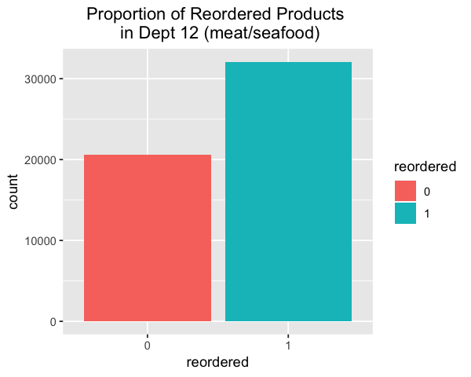

```r
dept12 <- Combined.Orders[Combined.Orders$department_id == 12,]

reorder.table12<- dept12 %>%
  count(reordered) %>%
  mutate(prop = prop.table(n))

as.data.frame(reorder.table12)

reorder12 <- dept12 %>%
  group_by(reordered) %>%
  summarize(count = n()) %>%
  mutate(proportion = count/sum(count))

reorder12 %>%
  ggplot(aes(x=reordered,y=count, fill=reordered))+
geom_bar(stat="identity")+ ggtitle("Proportion of Reordered Products \n in Dept 12 (meat/seafood)") + theme(plot.title = element_text(hjust = 0.5))
```

```r
item_list12 <- unique(dept12$product_id)

prop12<- c()
n = c()

for (prodid in item_list12){
    subset <- dept12[dept12$product_id == prodid,]
    avg = (nrow(subset[subset$reordered==1,]))/nrow(subset)

    prop12 <- append(prop12, avg)
    n = append(n, nrow(subset))
}

dept12proportions <- data.frame(item_list12,prop12,n)
names(dept12proportions)[1]<- 'product_id'
dept12proportions<- merge(dept12proportions, products, by='product_id')
dept12proportions<-dept12proportions %>% arrange(desc(dept12proportions$n))

head(dept12proportions, n=15)
```

A data.frame: 15 × 6

| product_id <int> | prop12 <dbl> | n <int> | product_name <fct> | aisle_id <int> | department_id <int> |
| --- | --- | --- | --- | --- | --- |
| 25890 | 0.7203591 | 3787 | Boneless Skinless Chicken Breasts | 49 | 12 |
| 38293 | 0.6815102 | 2066 | Ground Turkey Breast | 35 | 12 |
| 6046 | 0.7020798 | 1779 | Boneless Skinless Chicken Breast | 35 | 12 |
| 47672 | 0.6695769 | 1489 | Uncured Hickory Smoked Sunday Bacon | 106 | 12 |
| 5646 | 0.6835237 | 1226 | Organic Turkey Bacon | 106 | 12 |
| 45633 | 0.6210351 | 1198 | Organic Beef Hot Dogs | 106 | 12 |
| 17461 | 0.6814310 | 1174 | Air Chilled Organic Boneless Skinless Chicken Breasts | 35 | 12 |
| 10017 | 0.6493625 | 1098 | Tilapia Filet | 39 | 12 |
| 9339 | 0.6947271 | 1081 | Organic Chicken & Apple Sausage | 106 | 12 |
| 27695 | 0.6951673 | 1076 | Natural Chicken & Sage Breakfast Sausage | 106 | 12 |
| 13198 | 0.6952880 | 955 | 85% Lean Ground Beef | 122 | 12 |
| 12456 | 0.6473214 | 896 | Organic Sunday Bacon | 106 | 12 |
| 4421 | 0.5612245 | 882 | Organic Beef Uncured Hot Dogs | 106 | 12 |
| 21927 | 0.7262639 | 811 | Organic Boneless Skinless Chicken Breast | 35 | 12 |
| 9020 | 0.6377171 | 806 | Boneless Skinless Chicken Thighs | 35 | 12 |

A data.frame: 2 × 3

| reordered <fct> | n <int> | prop <dbl> |
| --- | --- | --- |
| 0 | 40929 | 0.5098154 |
| 1 | 39353 | 0.4901846 |

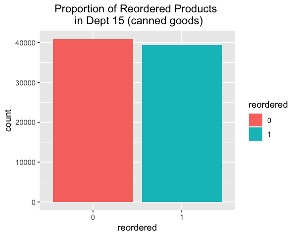

```r
dept15 <- Combined.Orders[Combined.Orders$department_id == 15,]

reorder.table15<- dept15 %>%
  count(reordered) %>%
  mutate(prop = prop.table(n))

as.data.frame(reorder.table15)

reorder15 <- dept15 %>%
  group_by(reordered) %>%
  summarize(count = n()) %>%
  mutate(proportion = count/sum(count))

reorder15 %>%
  ggplot(aes(x=reordered,y=count, fill=reordered))+
geom_bar(stat="identity") + ggtitle("Proportion of Reordered Products \n in Dept 15 (canned goods)") + theme(plot.title = element_text(hjust = 0.5))
```

```r
item_list15 <- unique(dept15$product_id)

prop15<- c()
n = c()

for (prodid in item_list15){
    subset <- dept15[dept15$product_id == prodid,]
    avg = (nrow(subset[subset$reordered==1,]))/nrow(subset)

    prop15 <- append(prop15, avg)
    n = append(n, nrow(subset))
}

dept15proportions <- data.frame(item_list15,prop15,n)
names(dept15proportions)[1]<- 'product_id'
dept15proportions<- merge(dept15proportions, products, by='product_id')
dept15proportions<-dept15proportions %>% arrange(desc(dept15proportions$n))

head(dept15proportions, n=15)
```

A data.frame: 15 × 6

| product_id <int> | prop15 <dbl> | n <int> | product_name <fct> | aisle_id <int> | department_id <int> |
| --- | --- | --- | --- | --- | --- |
| 27156 | 0.6182759 | 2900 | Organic Black Beans | 59 | 15 |
| 42768 | 0.5831123 | 2262 | Organic Garbanzo Beans | 59 | 15 |
| 28849 | 0.6348528 | 2106 | No Salt Added Black Beans | 59 | 15 |
| 890 | 0.5033475 | 1643 | Organic Diced Tomatoes | 81 | 15 |
| 7021 | 0.4450072 | 1382 | Organic Tomato Paste | 81 | 15 |
| 45535 | 0.4969088 | 1294 | Organic Low Sodium Chicken Broth | 69 | 15 |
| 26790 | 0.7570394 | 1243 | Organic AppleApple | 99 | 15 |
| 8670 | 0.4750890 | 1124 | Diced Tomatoes | 81 | 15 |
| 46720 | 0.4669951 | 1015 | Organic Free Range Chicken Broth | 69 | 15 |
| 35042 | 0.5390071 | 987 | Black Beans | 59 | 15 |
| 22395 | 0.4773196 | 970 | Tomato Sauce | 81 | 15 |
| 9092 | 0.5161290 | 961 | Organic Vegetable Broth | 69 | 15 |
| 44449 | 0.4796238 | 957 | Organic Tomato Sauce | 81 | 15 |
| 3376 | 0.5164718 | 941 | Organic Whole Kernel Sweet Corn No Salt Added | 81 | 15 |
| 11408 | 0.5096701 | 879 | Crushed Tomatoes | 81 | 15 |

## Model Performance

### Prediction and Accuracy

```r
attach(Combined.Orders)
set.seed(1)

Accuracy <- function(table)
{
 n11 <- table[1,1]
 n22 <- table[2,2]
 Total <- table[1,1]+table[2,2]+table[2,1]+table[1,2]
 Total
 return((n11+n22)/Total)
}
```

```r
ProbM1 <- predict.glm(Logistic.TestModel1, newdata = Test.Orders, type = "response")
PredM1 <- ifelse(ProbM1 > .5, "1" , "0")
TableM1 <- table(PredM1, Test.Orders$reordered)
TableM1
Accuracy(TableM1)
```

```
PredM1      0      1
     0  95350  42530
     1  84329 263392
```

0.738758775208453

```r
print('Sensitivity:')
sensitivity(TableM1)
print('Specificity:')
specificity(TableM1)
```

```
[1] "Sensitivity:"
```

0.530668581192015

```
[1] "Specificity:"
```

0.860977634821948

```r
ProbM2 <- predict.glm(Logistic.TestModel2, newdata = Test.Orders, type = "response")
PredM2 <- ifelse(ProbM2 > .5, "1" , "0")

TableM2 <- table(PredM2, Test.Orders$reordered)
TableM2

Accuracy(TableM2)
```

```
PredM2      0      1
     0  95348  42445
     1  84331 263477
```

0.738929697426488

```r
print('Sensitivity:')
sensitivity(TableM2)
print('Specificity:')
specificity(TableM2)
```

```
[1] "Sensitivity:"
```

0.530657450230689

```
[1] "Specificity:"
```

0.861255483423879

```r
# DIFFERENT?? WHY
ProbM2 <- predict.glm(Logistic.TestModel2, newdata = Test.Orders, type = "response")
PredM2 <- ifelse(ProbM2 > .5, "1" , "0")

TableM2 <- table(PredM2, Test.Orders$reordered)
TableM2

Accuracy(TableM2)
```

```
PredM2      0      1
     0  95348  42445
     1  84331 263477
```

0.738929697426488

## ROC Curve

When interpreting the classification error rates, how can we be sure that the best decision boundary for identifying a reorder=1 response should be when the likelihood, p=success > .5?

Depending on the business costs of Type I errors (false positive, ie a product/user/time observation is incorrectly recommended/estimated to reorder the product when in reality they would not reorder the product)and Type II errors (false negative, ie a product/user/time observation is not estimated to reorder the product when in reality they would want to reorder the product at thist time), we may want to adjust our decision boundary thresholds in order to minimize the two types of possible errors that can occur.

Thus, we will use a Receiver Operating Characteric (ROC) curve, which plots the true positive and false positive rates of the data at various decision boundary threshold settings.

```r
library(Epi)
```

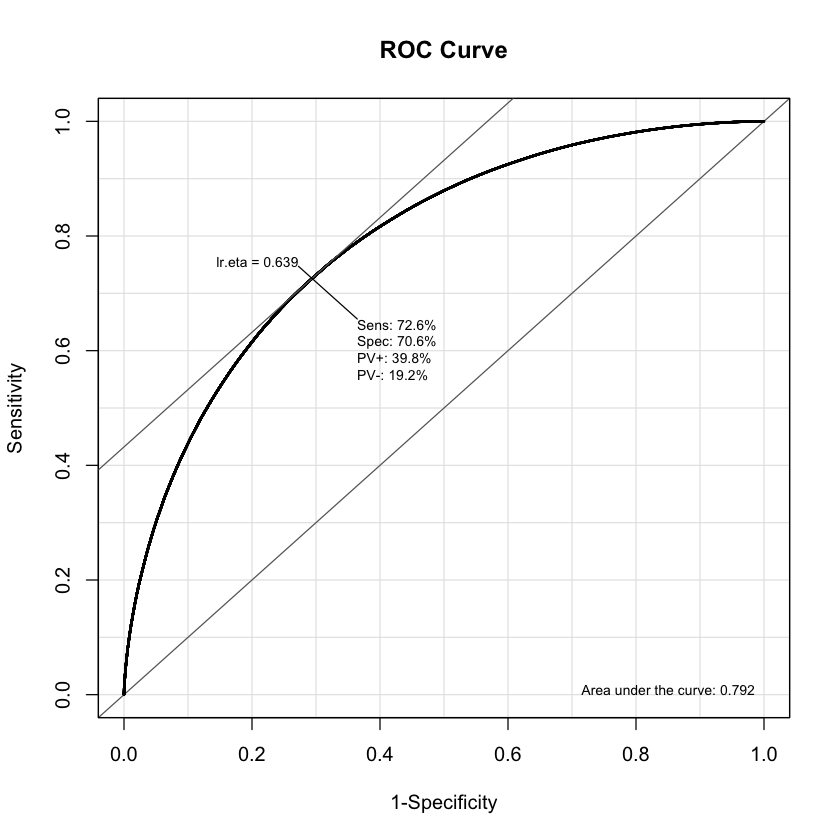

```r
ROC(form=(reordered ~ user_prop_reordered + proportion_reordered + product_orders_total + total_orders + add_to_cart_order + order_dow + days_since_prior_order + department_id) , data=Training.Orders, plot=
"ROC", MX=TRUE, MI=FALSE, main="ROC Curve")
```

#### According to the results above, we can see that the optimal decision boundary threshold for our data is at p(reordered=1) = .639.

With this new information, we can recalculate our accuracy, sensitivity, and specificity rates of our logistic regression model. As we can see below, the accuracy rate has decreased from 0.7389 to .7186; however, the important difference to note here is that the sensitivity and specificity are now closer to eachother (where previously they were 0.5307 and 0.8613 respectively).

#### All in all, the optimal decision boundary should be chosen with consideration of several business implications. Thus, for our purposes, we will leave this question aside and use the .5 decision threshold and associated accuracy rate for comparisons with the other two models.

```r
ProbM2 <- predict.glm(Logistic.TestModel2, newdata = Test.Orders, type = "response")
PredM2 <- ifelse(ProbM2 > .639, "1" , "0")

TableM2 <- table(PredM2, Test.Orders$reordered)
TableM2

Accuracy(TableM2)
```

```
PredM2      0      1
     0 126675  83639
     1  53004 222283
```

0.718610546518644

```r
print('Sensitivity:')
sensitivity(TableM2)
print('Specificity:')
specificity(TableM2)
```

```
[1] "Sensitivity:"
```

0.705007262952265

```
[1] "Specificity:"
```

0.72660024450677

## Model 2: Classification Tree

We will next look at the classification tree technique, which makes predictions about the response variable based on the mean responses of the training observations that belong to the leaves (or endpoints).

The tree model below, Tree.TestModel, uses the same predictors as the ones used in the previous logistic regression model, Logistic.TestModel2.

```r
library(rpart)
```

```r
Tree.TestModel <- rpart(reordered ~ user_prop_reordered + proportion_reordered + product_orders_total + total_orders + add_to_cart_order + order_dow + days_since_prior_order + department_id,method = "class", data = Training.Orders)
```

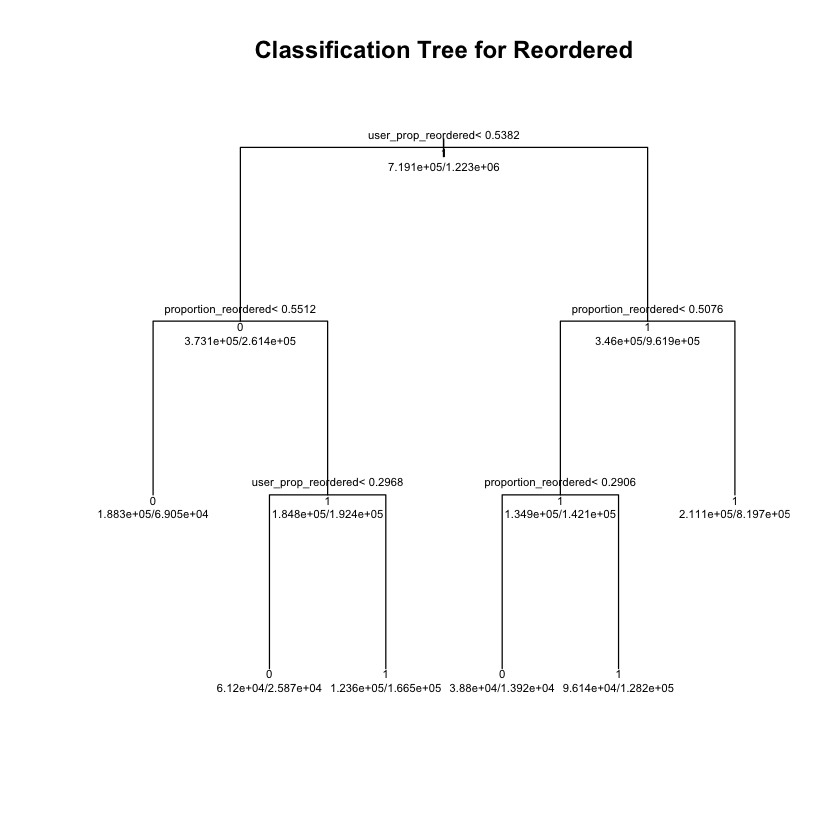

```r
plot(Tree.TestModel, uniform=TRUE, margin=.05,
   main="Classification Tree for Reordered")
text(Tree.TestModel, use.n=TRUE, all=TRUE, cex=.57)
```

### Cross validation using complexity parameter (cp)

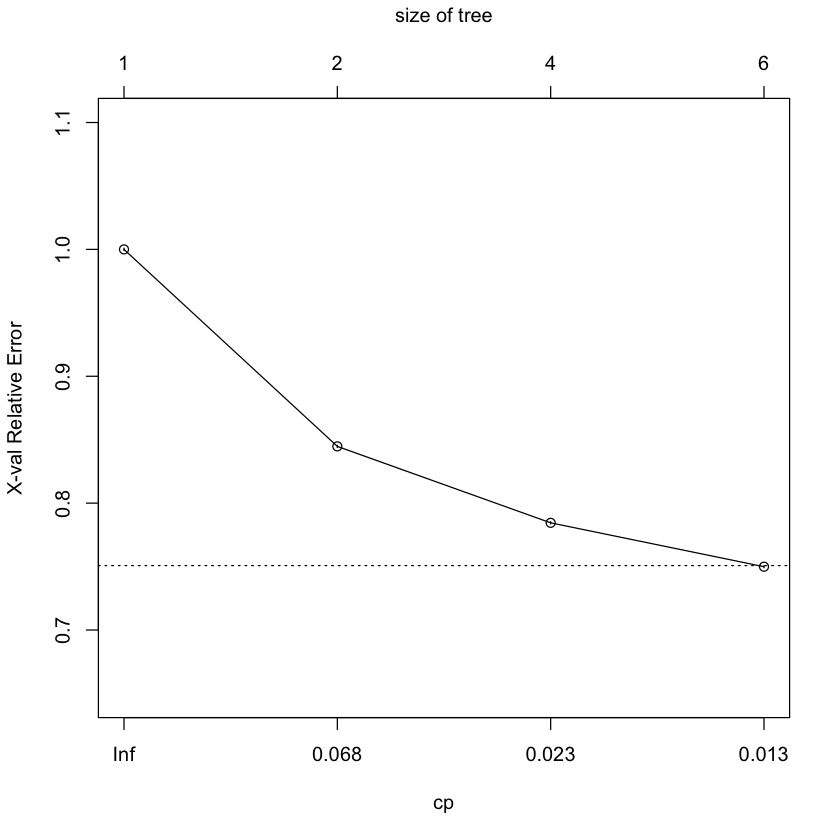

```r
Tree.TestModelR <- capture.output(summary(Tree.TestModel))
plotcp(Tree.TestModel)
```

#### The graph above and outputs below show that the relative error decreases as the complexity parameter decreases. We can see that the optimal complexity parameter value associated with the minimum error is .01.

```r
printcp(Tree.TestModel) # display the results

Tree.TestModel$cptable
```

```
Classification tree:
rpart(formula = reordered ~ user_prop_reordered + proportion_reordered +
    product_orders_total + total_orders + add_to_cart_order +
    order_dow + days_since_prior_order + department_id, data = Training.Orders,
    method = "class")

Variables actually used in tree construction:
[1] proportion_reordered user_prop_reordered

Root node error: 719122/1942400 = 0.37022

n= 1942400

        CP nsplit rel error  xerror       xstd
1 0.155263      0   1.00000 1.00000 0.00093582
2 0.029823      1   0.84474 0.84474 0.00089851
3 0.017304      3   0.78509 0.78448 0.00087981
4 0.010000      5   0.75048 0.74991 0.00086792
```

A matrix: 4 × 5 of type dbl

| CP | nsplit | rel error | xerror | xstd |
| --- | --- | --- | --- | --- |
| 0.15526295 | 0 | 1.0000000 | 1.0000000 | 0.0009358192 |
| 0.02982317 | 1 | 0.8447371 | 0.8447440 | 0.0008985051 |
| 0.01730374 | 3 | 0.7850907 | 0.7844802 | 0.0008798050 |
| 0.01000000 | 5 | 0.7504832 | 0.7499061 | 0.0008679229 |

```r
Tree.TestModel$cptable[which.min(Tree.TestModel$cptable[,'xerror']), 'CP']
```

0.01

#### Pruning

Normally, we would want to prune the tree in order to prevent overfitting and decrease the amount of variance from our original tree; however, the optimal CP value came out to be the same as the default CP value for the rpart tree method. Thus, we will keep the original tree model built.

```r
Pred.Tree <- predict(Tree.TestModel, newdata = Test.Orders, type = "class")
Tree.Table <- table(Pred.Tree, Test.Orders$reordered)
Tree.Table

Accuracy(Tree.Table)
```

```
Pred.Tree      0      1
        0  71961  27142
        1 107718 278780
```

0.722282285250648

```r
print('Sensitivity:')
sensitivity(Tree.Table)
print('Specificity:')
specificity(Tree.Table)
```

```
[1] "Sensitivity:"
```

0.400497553971249

```
[1] "Specificity:"
```

0.911278038192742

### Random Forest

To improve upon the tree method used above, a random forest allows a way to make decorrelated trees to lower the variance of the model. By forcing each split in the tree to be selected based on only a subset of all of the predictors available for use, the random forest prevents a dominant predictor from ruling the results of the trees built.

As demonstrated below, the randomForest function from the R package will not run on large data frames. In order for the randomForest to run, we had to cut the data by 50% (with 971200 observations).

```r
library(randomForest)

# First attempt: Error from the training set being too large :(
randomForest.fit <- randomForest(reordered ~ user_prop_reordered + proportion_reordered + product_orders_total + total_orders + add_to_cart_order + order_dow + days_since_prior_order + department_id,   data=Training.Orders)
```

```
Error in randomForest.default(m, y, ...): long vectors (argument 26) are not supported in .C
Traceback:

1. randomForest(reordered ~ user_prop_reordered + proportion_reordered +
 .     product_orders_total + total_orders + add_to_cart_order +
 .     order_dow + days_since_prior_order + department_id, data = Training.Orders)
2. randomForest.formula(reordered ~ user_prop_reordered + proportion_reordered +
 .     product_orders_total + total_orders + add_to_cart_order +
 .     order_dow + days_since_prior_order + department_id, data = Training.Orders)
3. randomForest.default(m, y, ...)
```

```r
# Split the data in half

set.seed(1)
subset <- sample(1:nrow(Training.Orders), nrow(Training.Orders)/2)
Training.Orders2 <- Training.Orders[subset,]
```

```r
nrow(Training.Orders2)
```

971200

```r
# Second attempt
randomForest.fit2 <- randomForest(reordered ~ user_prop_reordered + proportion_reordered + product_orders_total + total_orders + add_to_cart_order + order_dow + days_since_prior_order + department_id,   data=Training.Orders2)
```

```r
print(randomForest.fit2)
importance(randomForest.fit2)
```

```
Call:
 randomForest(formula = reordered ~ user_prop_reordered + proportion_reordered +      product_orders_total + total_orders + add_to_cart_order +      order_dow + days_since_prior_order + department_id, data = Training.Orders2)
               Type of random forest: classification
                     Number of trees: 500
No. of variables tried at each split: 2

        OOB estimate of  error rate: 26.07%
Confusion matrix:
       0      1 class.error
0 191642 168236   0.4674806
1  84935 526387   0.1389366
```

A matrix: 8 × 1 of type dbl

|  | MeanDecreaseGini |
| --- | --- |
| user_prop_reordered | 100512.53 |
| proportion_reordered | 81943.24 |
| product_orders_total | 53429.74 |
| total_orders | 62535.25 |
| add_to_cart_order | 40436.10 |
| order_dow | 32692.11 |
| days_since_prior_order | 38478.58 |
| department_id | 32674.32 |

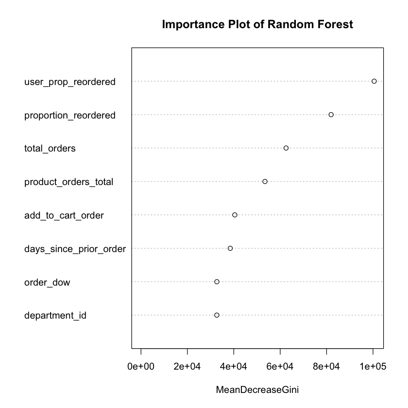

```r
varImpPlot(randomForest.fit2, main='Importance Plot of Random Forest')
```

## Model 3: K Nearest Neighbor (KNN) Classification

Next we will look at K Nearest Neighbor (KNN) classification, which applies distance formulas to locate points that are nearest to our training data points. Once this is done, a prediction model is fitted using the labels that are the most frequently out of each k neighbor group for each data point.

An important piece of information to consider is that the KNN classification requires that all predictors used in the model to be numeric. Thus, we will take out of consideration the following variables, which are not numeric or ordinal: user_id, eval_set, order_number, order_dow, product_name, product_id, aisle_id, department_id)

As for the ordinal categorical predictor variables (ie total_orders, product_orders_total, add_to_cart_order, order_hour_of_day), we will coerce these variables to be continuous instead of discrete.

```r
library(MASS)
library(class)
```

```r
train.y <- Training.Orders[9]
train.X <- Training.Orders[c(-1, -4, -9, -10, -11, -12, -15, -16, -17, -18 )]

test.X <- Test.Orders[c(-1, -4, -9, -10, -11, -12, -15, -16, -17, -18 )]
```

```r
train.y = train.y[,1]
```

```r
nrow(train.X)
length(train.y)
nrow(test.X)
```

1942400

1942400

485601

```r
head(train.X)
```

A data.frame: 6 × 8

|  | total_orders <int> | user_prop_reordered <dbl> | proportion_reordered <dbl> | product_orders_total <int> | order_id <int> | add_to_cart_order <int> | order_hour_of_day <int> | days_since_prior_order <int> |
| --- | --- | --- | --- | --- | --- | --- | --- | --- |
| 2367507 | 30 | 0.7000000 | 0.6840405 | 11147 | 1565475 | 5 | 0 | 30 |
| 1582830 | 147 | 0.7142857 | 0.6295110 | 8119 | 182523 | 20 | 13 | 13 |
| 912381 | 33 | 0.6666667 | 0.4566474 | 173 | 3119618 | 3 | 6 | 30 |
| 2261718 | 31 | 0.7419355 | 0.7200675 | 593 | 2512048 | 6 | 12 | 8 |
| 1431980 | 297 | 0.7609428 | 0.7500000 | 24 | 763357 | 11 | 14 | 7 |
| 682798 | 84 | 0.6547619 | 0.6628571 | 875 | 2902612 | 14 | 13 | 14 |

```r
attach(train.X)
```

#### Often with KNN, the scale of the predictor variables should be considered so that variables with larger numbers will not dominant the classification over those with smaller values (since distances between points are evaluated to locate the K nearest neighbors).

Thus, below we make sure to normalize each of the variables used in the KNN classification training and test sets.

```r
normalize <- function(x){
    return((x-min(x)) / (max(x)-min(x)))
}
```

```r
train.X.normalized <- as.data.frame(lapply(train.X, normalize))
test.X.normalized <- as.data.frame(lapply(test.X, normalize))
```

```r
set.seed(1)

# Arbitrarily chose a K value of 5 here, which is a common choice for industry use
knn.pred = knn(train.X.normalized,test.X.normalized,train.y ,k=5)
```

```r
test.y <- Test.Orders[9]
test.y = test.y[,1]
```

```r
knn.table<- table(knn.pred, test.y)
knn.table
Accuracy(knn.table)
```

```
        test.y
knn.pred      0      1
       0  94310  54707
       1  85369 251215
```

0.711540956464258

```r
print('Sensitivity:')
sensitivity(knn.table)
print('Specificity:')
specificity(knn.table)
```

```
[1] "Sensitivity:"
```

0.524880481302768

```
[1] "Specificity:"
```

0.821173370989991

```r
levels(knn.pred)
knn.pred[1:15]
```

1. '0'

2. '1'

1. 1

2. 1

3. 1

4. 1

5. 1

6. 1

7. 0

8. 1

9. 1

10. 0

11. 1

12. 1

13. 0

14. 1

15. 1

**Levels**:**

1. '0'

2. '1'

```r
knn.table<- table(knn.pred, test.y)
knn.table
Accuracy(knn.table)
```

```
        test.y
knn.pred      0      1
       0  94310  54707
       1  85369 251215
```

0.711540956464258

### K-Fold Cross Validation to Optimize K for KNN Classification

Cross-Validation is a commonly used method to to test the performance reliability of a model on different groupings of unseen data. For KNN classification, we will consider a variety of different K values that select the K nearest neighbors of the training data. We will compute 10 different KNN classification models using different K values from 1 to 10. We will then select the model with the lowest test/validation error as the final model to use.

```r
train.normalized <- cbind(train.X.normalized, train.y)
names(train.normalized)[9] <- 'reordered'
attach(train.normalized)
```

```r
# In order to make the training and test samples the same size for cross-validation evaluation
set.seed(1)
Training.Orders2 <- Training.Orders[sample(1:nrow(train.X.normalized), 485601),]
```

```r
train.y2 <- Training.Orders2[9]
train.X2 <- Training.Orders2[c(-1, -4, -9, -10, -11, -12, -15, -16, -17, -18 )]
train.y2 = train.y2[,1]
```

```r
train.X.normalized2 <- as.data.frame(lapply(train.X2, normalize))
```

```r
set.seed(1)

# Creating the 5 lists of indices that represent the 5 folds of the cross validation
idx <- createFolds(train.y2, k=5)
```

```r
idx[[1]]
```

1. 10

2. 14

3. 18

4. 20

5. 26

6. 29

7. 31

8. 48

9. 53

10. 54

11. 60

12. 72

13. 73

14. 84

15. 85

16. 91

17. 94

18. 95

19. 97

20. 99

```r
set.seed(1)

ks<- 1:10

res <- sapply(ks, function(k) {
  # try out each version of k from 1 to 10
  res.k <- sapply(seq_along(idx), function(i) {
    # looping over each of the 5 cross-validation folds to create predicted classifications of the training data
    pred <- knn(train=train.X.normalized2[-idx[[i]], ],
                test=test.X.normalized[idx[[i]], ],
                cl=train.y2[-idx[[i]]], k = k)
    # calculation of ratio of misclassified training samples
    mean(train.y2[idx[[i]]] != pred)
  })
  # averaging the error rates over the 5 folds per K-value group
  mean(res.k)
})
```

#### The outputted values are the error rates of each of the 10 different KNN models (using a range of K values from 1 to 10). From the plot below, we can see that the model with the minimal error considers K=10 nearest neighbors.

1. 0.460814533256717

2. 0.462124251621861

3. 0.451230541581707

4. 0.450579795905251

5. 0.446941007679733

6. 0.446774206991236

7. 0.444366880201086

8. 0.44426391424615

9. 0.442661774452777

10. 0.442437310042531

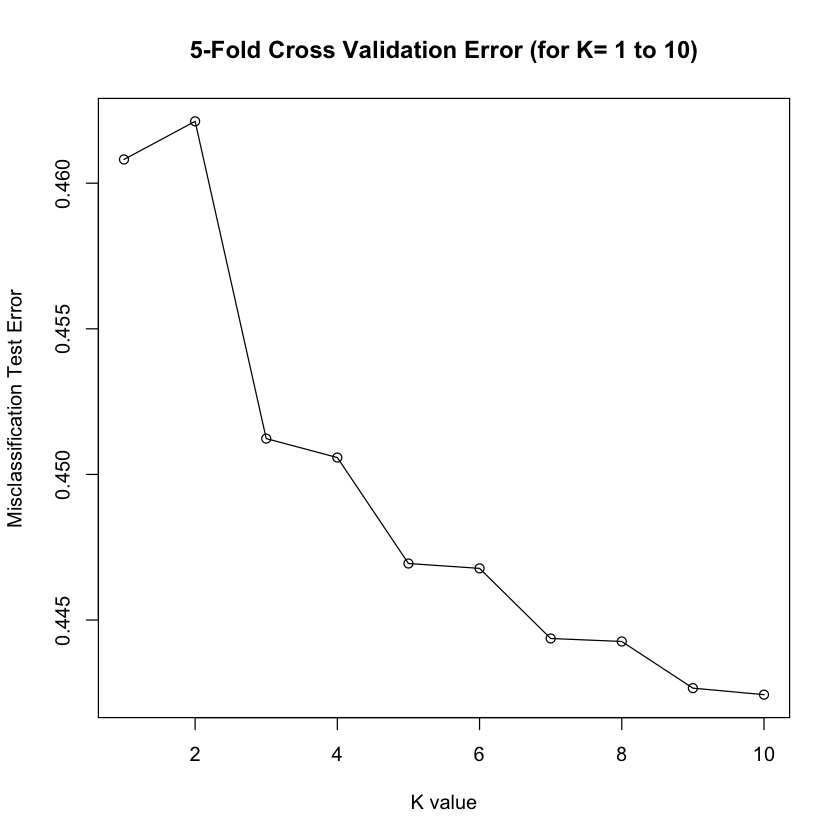

```r
res

plot(ks, res, type="o",xlab='K value', ylab="Misclassification Test Error", main='5-Fold Cross Validation Error (for K= 1 to 10)')
```

```r
which.min(res)
```

10

```r
res[10]
```

0.442437310042531

```r
set.seed(1)

knn.pred2 = knn(train.X.normalized,test.X.normalized,train.y ,k=10)
```

```r
knn.table2<- table(knn.pred2, test.y)
knn.table2
Accuracy(knn.table2)
```

```
        test.y
knn.pred      0      1
       0  92965  48051
       1  86714 257871
```

0.722477919114664

```r
print('Sensitivity:')
sensitivity(knn.table2)
print('Specificity:')
specificity(knn.table2)
```

```
[1] "Sensitivity:"
```

0.517394909811386

```
[1] "Specificity:"
```

0.842930550924746

The final accuracy rate of the knn.pred2 model is 72.24%, which is an improvement from the previous accuracy rate of 71.15% from the original knn.pred model using K=5 nearest neighbors. Next let's compare the different models below!

## Conclusion:

#### Interaction Terms and Understanding:

Another factor to consider is the use of interaction terms. To keep the models simple, we chose to not implement interaction terms; however, since the likelihood of a user reordering a product involves a nuanced relationship between the user to specific products, it would make sense to include interaction terms to account for the variety of relationships between the two variables. Thus, to improve upon all of the three models provided, it is recommended to include interaction terms between product_id's and user_ids's.

#### Subset Selection:

Thus, for further exploration, it is recommended to consider models that use a subset of the variables we have considered. There are various subset selection methods that can applied such as backward and forward stepwise regression, principal component analysis, and lasso and ridge regression that will help eliminate some of the unnecessary variables. Additionally, one should take a look at a correlation map in order to identify some of the highest correlated variables to take out of the model (to minimize the chance of overfitting).

### References:

https://www.kaggle.com/c/instacart-market-basket-analysis

https://tech.instacart.com/3-million-instacart-orders-open-sourced-d40d29ead6f2

[figure not shown]